# Overview of `data`

**Overview**

Table Overview

| Columns | 28 |
| --- | --- |
| Rows | 1,000 |
| `NA`s | 972 (3.47%) |
| Duplicate Rows | 0 |

Column Types

| character | 18 |
| --- | --- |
| integer | 4 |
| numeric | 4 |
| Date | 2 |

**Reproducibility**

Reproducibility Information

| Scan Build Time | `2025-10-02 13:41:36` |
| --- | --- |
| **pointblank** Version | `0.12.2` |
| **R** Version | R version 4.5.0 (2025–04–11) *How About a Twenty–Six* |
| Operating System | `aarch64-apple-darwin20` |

# Missing Values

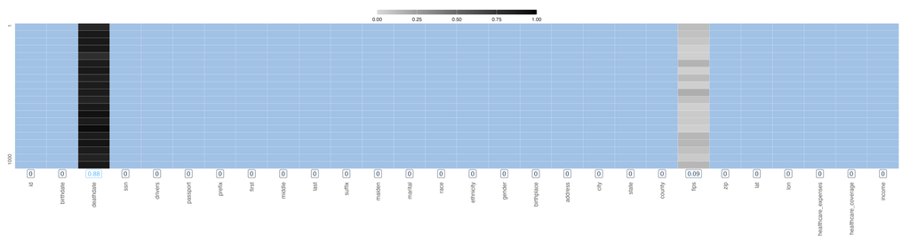

# Sample

|  | id | birthdate | deathdate | ssn | drivers | passport | prefix | first | middle | last | suffix | maiden | marital | race | ethnicity | gender | birthplace | address | city | state | county | fips | zip | lat | lon | healthcare_expenses | healthcare_coverage | income |
| --- | --- | --- | --- | --- | --- | --- | --- | --- | --- | --- | --- | --- | --- | --- | --- | --- | --- | --- | --- | --- | --- | --- | --- | --- | --- | --- | --- | --- |
| 1 | 239 | 1952-01-25 | 2019-02-12 | 999-95-6994 | S99957114 | X65202292X | Mr. | Neal | Arlen | Yundt |  |  | M | white | nonhispanic | M | Badger Alaska US | 486 Willms Key Suite 43 | Sutton-Alpine | Alaska | Matanuska-Susitna Borough | `NA` | 0 | 61.78086 | -148.88521 | 604277.35 | 4632588.60 | 13425 |
| 2 | 58571 | 1962-07-05 | `NA` | 999-54-7101 | S99994435 | X80776750X | Mr. | Parker | Ira | Rohan |  |  | M | white | nonhispanic | M | Centerton Arkansas US | 626 Schimmel Boulevard Unit 13 | Bella Vista | Arkansas | Benton County | 5007 | 72768 | 36.44283 | -94.33223 | 84048.08 | 91540.56 | 25534 |
| 3 | 406 | 1972-07-26 | `NA` | 999-16-8101 | S99955639 | X16017633X | Mrs. | Alyse |  | Gorczany |  | Robel | M | white | nonhispanic | F | Foley Alabama US | 404 Schmitt Way Apt 25 | Ozark | Alabama | Dale County | 1045 | 36362 | 31.37628 | -85.71499 | 1674494.54 | 382305.36 | 57789 |
| 4 | 57575 | 1986-01-31 | `NA` | 999-18-2129 | S99951361 | X58081714X | Mrs. | Eneida |  | Simonis |  | Greenfelder | M | white | nonhispanic | F | Forrest City Arkansas US | 643 Keeling Dam Apt 29 | Pocahontas | Arkansas | Randolph County | 5121 | 72455 | 36.36817 | -91.00155 | 185214.20 | 720452.02 | 67415 |
| 5 | 15598981 | 2021-11-08 | `NA` | 999-79-4838 |  |  |  | Leroy | Norman | Schimmel |  |  |  | black | nonhispanic | M | Madison Alabama US | 487 Feeney Ferry Unit 2 | Theodore | Alabama | Mobile County | 1097 | 36582 | 30.47634 | -88.20207 | 536.84 | 6358.69 | 23056 |
| 6..995 |  |  |  |  |  |  |  |  |  |  |  |  |  |  |  |  |  |  |  |  |  |  |  |  |  |  |  |  |
| 996 | 58463 | 2006-04-22 | `NA` | 999-26-8258 | S99984244 |  | Mr. | Bart |  | Stroman |  |  |  | black | nonhispanic | M | Montgomery Alabama US | 745 Goodwin Landing | Birmingham | Alabama | Jefferson County | 1073 | 35212 | 33.40850 | -86.93119 | 34879.80 | 38646.24 | 134060 |
| 997 | 57034 | 2006-04-05 | `NA` | 999-61-8444 | S99994551 |  | Mr. | Marcelo | Abe | Wolf |  |  |  | white | nonhispanic | M | Chandler Arizona US | 838 Collins Throughway Suite 10 | Phoenix | Arizona | Maricopa County | 4013 | 85008 | 33.74952 | -112.17715 | 65375.45 | 31677.13 | 28624 |
| 998 | 55997 | 1988-08-22 | `NA` | 999-59-6605 | S99990009 | X28252364X | Mrs. | Robbin |  | Dicki |  | Schneider | M | black | nonhispanic | F | Theodore Alabama US | 386 Parker Neck | Oxford | Alabama | Calhoun County | 1121 | 36268 | 33.64394 | -85.91119 | 183738.80 | 668081.26 | 62436 |
| 999 | 56764 | 1958-06-06 | 2022-07-30 | 999-83-7722 | S99933049 | X37194560X | Mr. | Chris | Moshe | Reichel |  |  | M | white | nonhispanic | M | Medford Massachusetts US | 1023 Hamill Brook Unit 67 | Leominster | Massachusetts | Worcester County | 25027 | 1453 | 42.53502 | -71.80265 | 10803.25 | 130087.61 | 10705 |
| 1000 | 575 | 1998-04-30 | `NA` | 999-35-1153 | S99987436 | X36978405X | Mr. | Doug | Forest | Trantow |  |  |  | white | nonhispanic | M | Vestavia Hills Alabama US | 724 McGlynn Well | Bridgeport | Alabama | Jackson County | 1071 | 35740 | 34.98585 | -85.76824 | 25302.35 | 42194.46 | 10377 |

# Variables

id  
`integer`

| Distinct | 1,000 |
| --- | --- |
| `NA`s | 0 |
| `Inf`/`-Inf` | 0 |

| Mean | 1,180,846.22 |
| --- | --- |
| Minimum | 6 |
| Maximum | 15,599,111 |

**Statistics**

Quantile Statistics

| Minimum | 6.00 |
| --- | --- |
| 5th Percentile | 348.95 |
| Q1 | 55,115.25 |
| Median | 56,805.00 |
| Q3 | 58,696.25 |
| 95th Percentile | 15,598,838.05 |
| Maximum | 15,599,111.00 |
| Range | 15,599,105.00 |
| IQR | 3,581.00 |

Descriptive Statistics

| Mean | 1,180,846.22 |
| --- | --- |
| Variance | 16,387,214,798,344.90 |
| Standard Deviation | 4,048,112.50 |
| Coefficient of Variation | 3.43 |

**Common Values**

| Value | Count | Frequency |
| --- | --- | --- |
| 6 | 1 | 0.1% |
| 18 | 1 | 0.1% |
| 25 | 1 | 0.1% |
| 29 | 1 | 0.1% |
| 31 | 1 | 0.1% |
| 36 | 1 | 0.1% |
| 47 | 1 | 0.1% |
| 49 | 1 | 0.1% |
| 56 | 1 | 0.1% |
| **Other Values** (990) | 990 | 99.0% |

**Max/Min Slices**

| Value | Count | Frequency |
| --- | --- | --- |
| 6 | 1 | 0.10% |
| 18 | 1 | 0.10% |
| 25 | 1 | 0.10% |
| 29 | 1 | 0.10% |
| 31 | 1 | 0.10% |
| 36 | 1 | 0.10% |
| 47 | 1 | 0.10% |
| 49 | 1 | 0.10% |
| 56 | 1 | 0.10% |
| 62 | 1 | 0.10% |

Minimum Values

| Value | Count | Frequency |
| --- | --- | --- |
| 6 | 1 | 0.10% |
| 18 | 1 | 0.10% |
| 25 | 1 | 0.10% |
| 29 | 1 | 0.10% |
| 31 | 1 | 0.10% |
| 36 | 1 | 0.10% |
| 47 | 1 | 0.10% |
| 49 | 1 | 0.10% |
| 56 | 1 | 0.10% |
| 62 | 1 | 0.10% |

birthdate  
`date`

| Distinct | 963 |
| --- | --- |
| `NA`s | 0 |
| `Inf`/`-Inf` | 0 |

deathdate  
`date`

| Distinct | 118 |
| --- | --- |
| `NA`s | 882 |
| `Inf`/`-Inf` | 0 |

ssn  
`character`

| Distinct | 1,000 |
| --- | --- |
| `NA`s | 0 |
| `Inf`/`-Inf` | 0 |

**Common Values**

| Value | Count | Frequency |
| --- | --- | --- |
| 999-10-1203 | 1 | 0.1% |
| 999-10-3679 | 1 | 0.1% |
| 999-10-4726 | 1 | 0.1% |
| 999-10-5030 | 1 | 0.1% |
| 999-10-5161 | 1 | 0.1% |
| 999-10-8997 | 1 | 0.1% |
| 999-10-9433 | 1 | 0.1% |
| 999-11-1392 | 1 | 0.1% |
| 999-11-1591 | 1 | 0.1% |
| **Other Values** (990) | 990 | 99.0% |

**String Lengths**

String Lengths

| Mean | 11.0 |
| --- | --- |
| Minimum | 11.0 |
| Maximum | 11.0 |

Histogram

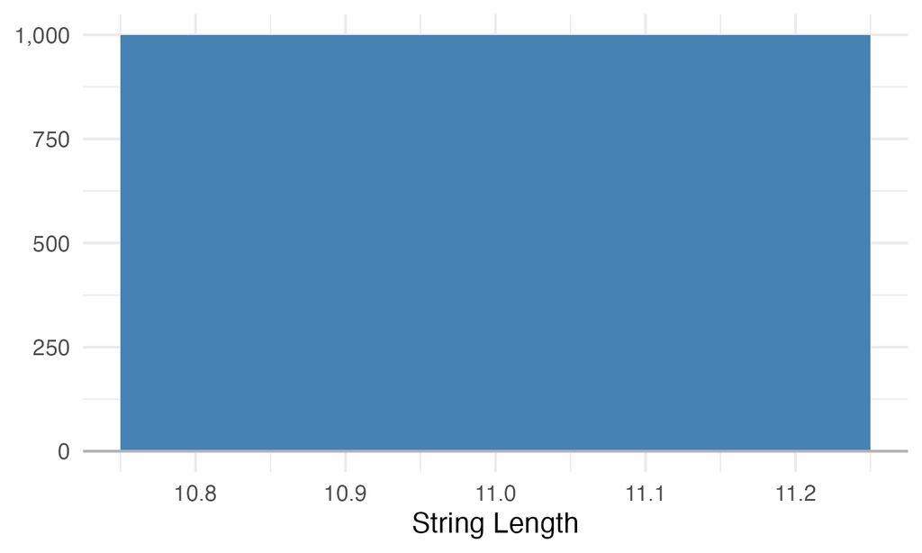

drivers  
`character`

| Distinct | 766 |
| --- | --- |
| `NA`s | 0 |
| `Inf`/`-Inf` | 0 |

**Common Values**

| Value | Count | Frequency |
| --- | --- | --- |
|  | 230 | 23.0% |
| S99917886 | 2 | 0.2% |
| S99929346 | 2 | 0.2% |
| S99949782 | 2 | 0.2% |
| S99959780 | 2 | 0.2% |
| S99985428 | 2 | 0.2% |
| S99910078 | 1 | 0.1% |
| S99910229 | 1 | 0.1% |
| S99910252 | 1 | 0.1% |
| **Other Values** (756) | 756 | 75.6% |

**String Lengths**

String Lengths

| Mean | 6.9 |
| --- | --- |
| Minimum | 0.0 |
| Maximum | 9.0 |

Histogram

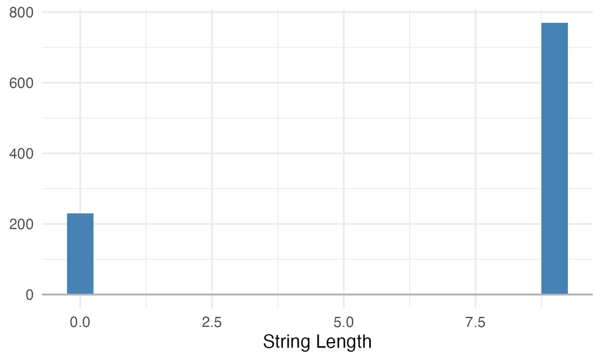

passport  
`character`

| Distinct | 728 |
| --- | --- |
| `NA`s | 0 |
| `Inf`/`-Inf` | 0 |

**Common Values**

| Value | Count | Frequency |
| --- | --- | --- |
|  | 273 | 27.3% |
| X10140625X | 1 | 0.1% |
| X10142736X | 1 | 0.1% |
| X10273849X | 1 | 0.1% |
| X10446457X | 1 | 0.1% |
| X10557278X | 1 | 0.1% |
| X10593122X | 1 | 0.1% |
| X10613877X | 1 | 0.1% |
| X10732211X | 1 | 0.1% |
| **Other Values** (718) | 718 | 71.8% |

**String Lengths**

String Lengths

| Mean | 7.2 |
| --- | --- |
| Minimum | 0.0 |
| Maximum | 10.0 |

Histogram

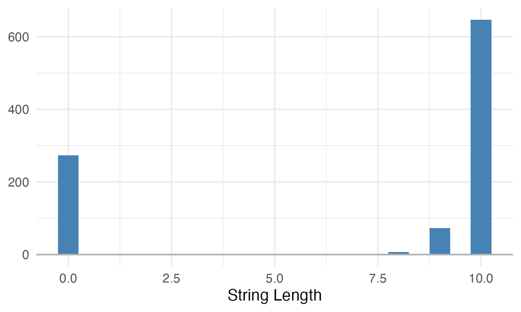

prefix  
`character`

| Distinct | 4 |
| --- | --- |
| `NA`s | 0 |
| `Inf`/`-Inf` | 0 |

**Common Values**

| Value | Count | Frequency |
| --- | --- | --- |
| Mr. | 373 | 37.3% |
|  | 247 | 24.7% |
| Mrs. | 241 | 24.1% |
| Ms. | 139 | 13.9% |
| **Other Values** (0) | 0 | 0.0% |

**String Lengths**

String Lengths

| Mean | 2.5 |
| --- | --- |
| Minimum | 0.0 |
| Maximum | 4.0 |

Histogram

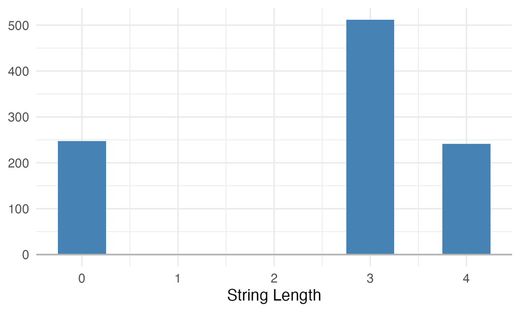

first  
`character`

| Distinct | 875 |
| --- | --- |
| `NA`s | 0 |
| `Inf`/`-Inf` | 0 |

**Common Values**

| Value | Count | Frequency |
| --- | --- | --- |
| Errol | 5 | 0.5% |
| Odell | 4 | 0.4% |
| Diego | 3 | 0.3% |
| Elsa | 3 | 0.3% |
| Florencio | 3 | 0.3% |
| Gabriel | 3 | 0.3% |
| Gus | 3 | 0.3% |
| Jerónimo | 3 | 0.3% |
| Justin | 3 | 0.3% |
| **Other Values** (967) | 967 | 96.7% |

**String Lengths**

String Lengths

| Mean | 5.9 |
| --- | --- |
| Minimum | 2.0 |
| Maximum | 13.0 |

Histogram

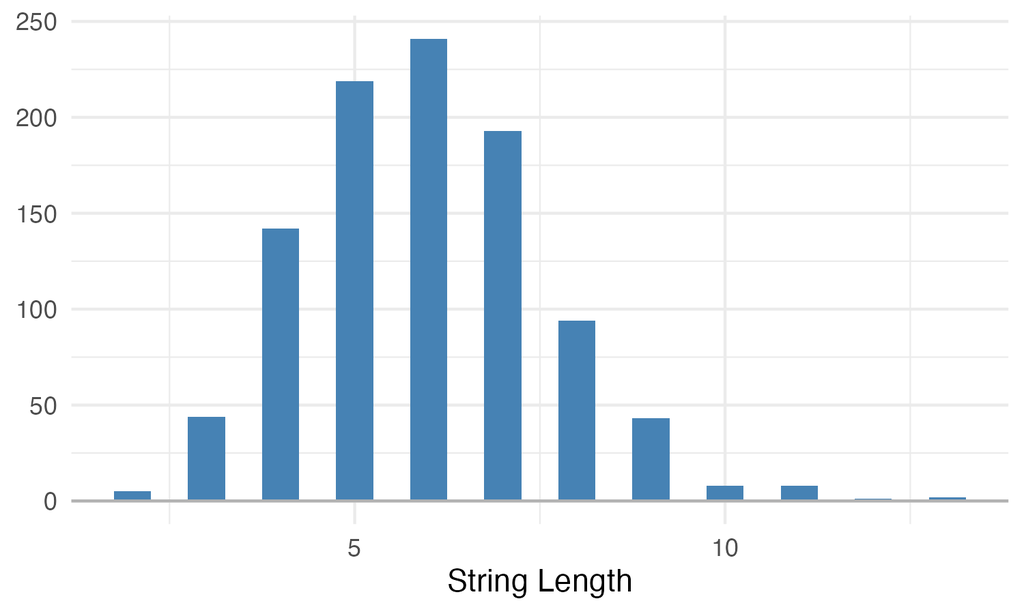

middle  
`character`

| Distinct | 719 |
| --- | --- |
| `NA`s | 0 |
| `Inf`/`-Inf` | 0 |

**Common Values**

| Value | Count | Frequency |
| --- | --- | --- |
|  | 194 | 19.4% |
| Harlan | 4 | 0.4% |
| Arturo | 3 | 0.3% |
| Carroll | 3 | 0.3% |
| Elijah | 3 | 0.3% |
| Jerald | 3 | 0.3% |
| Jerome | 3 | 0.3% |
| Mario | 3 | 0.3% |
| Robert | 3 | 0.3% |
| **Other Values** (778) | 778 | 77.8% |

**String Lengths**

String Lengths

| Mean | 4.8 |
| --- | --- |
| Minimum | 0.0 |
| Maximum | 13.0 |

Histogram

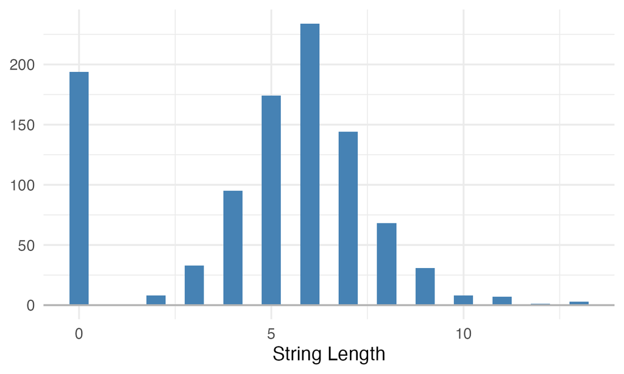

last  
`character`

| Distinct | 483 |
| --- | --- |
| `NA`s | 0 |
| `Inf`/`-Inf` | 0 |

**Common Values**

| Value | Count | Frequency |
| --- | --- | --- |
| Braun | 6 | 0.6% |
| Medhurst | 6 | 0.6% |
| Raynor | 6 | 0.6% |
| Runolfsson | 6 | 0.6% |
| Stokes | 6 | 0.6% |
| Will | 6 | 0.6% |
| Altenwerth | 5 | 0.5% |
| Conroy | 5 | 0.5% |
| Farrell | 5 | 0.5% |
| **Other Values** (944) | 944 | 94.4% |

**String Lengths**

String Lengths

| Mean | 6.6 |
| --- | --- |
| Minimum | 3.0 |
| Maximum | 13.0 |

Histogram

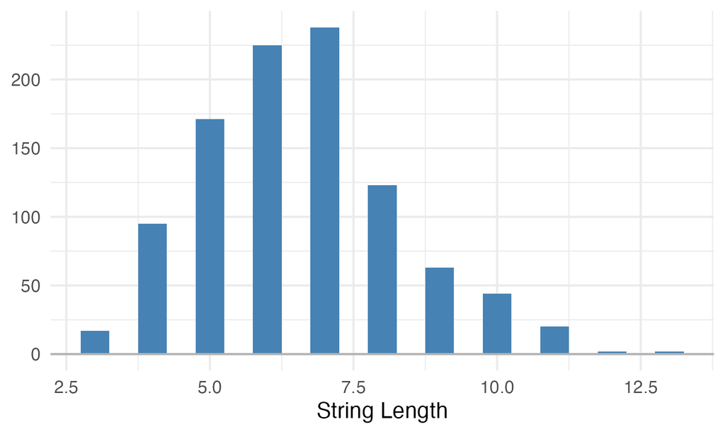

suffix  
`character`

| Distinct | 4 |
| --- | --- |
| `NA`s | 0 |
| `Inf`/`-Inf` | 0 |

**Common Values**

| Value | Count | Frequency |
| --- | --- | --- |
|  | 993 | 99.3% |
| PhD | 3 | 0.3% |
| JD | 2 | 0.2% |
| MD | 2 | 0.2% |
| **Other Values** (0) | 0 | 0.0% |

**String Lengths**

String Lengths

| Mean | 0.0 |
| --- | --- |
| Minimum | 0.0 |
| Maximum | 3.0 |

Histogram

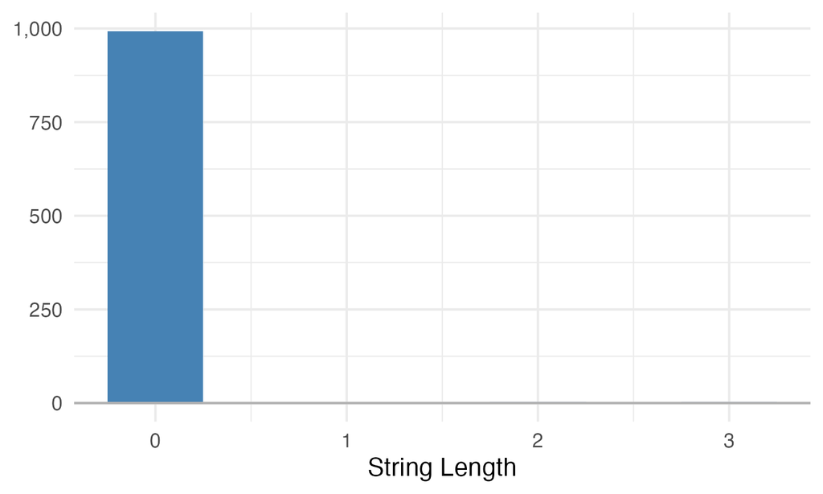

maiden  
`character`

| Distinct | 199 |
| --- | --- |
| `NA`s | 0 |
| `Inf`/`-Inf` | 0 |

**Common Values**

| Value | Count | Frequency |
| --- | --- | --- |
|  | 759 | 75.9% |
| Dach | 3 | 0.3% |
| Hegmann | 3 | 0.3% |
| Kohler | 3 | 0.3% |
| Mitchell | 3 | 0.3% |
| Olson | 3 | 0.3% |
| Schaefer | 3 | 0.3% |
| Thompson | 3 | 0.3% |
| Beatty | 2 | 0.2% |
| **Other Values** (216) | 216 | 21.6% |

**String Lengths**

String Lengths

| Mean | 1.5 |
| --- | --- |
| Minimum | 0.0 |
| Maximum | 12.0 |

Histogram

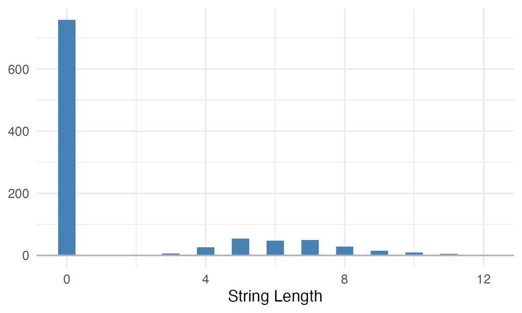

marital  
`character`

| Distinct | 5 |
| --- | --- |
| `NA`s | 0 |
| `Inf`/`-Inf` | 0 |

**Common Values**

| Value | Count | Frequency |
| --- | --- | --- |
| M | 392 | 39.2% |
|  | 369 | 36.9% |
| S | 130 | 13.0% |
| D | 81 | 8.1% |
| W | 28 | 2.8% |
| **Other Values** (0) | 0 | 0.0% |

**String Lengths**

String Lengths

| Mean | 0.6 |
| --- | --- |
| Minimum | 0.0 |
| Maximum | 1.0 |

Histogram

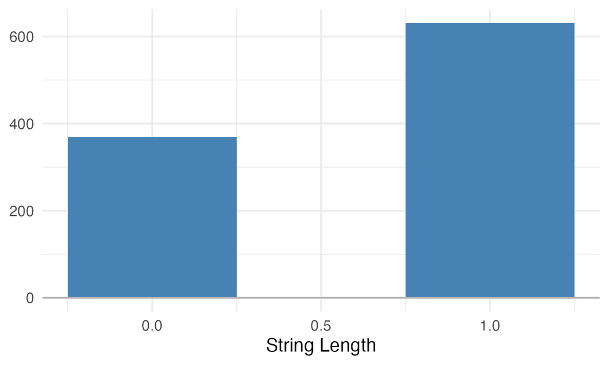

race  
`character`

| Distinct | 6 |
| --- | --- |
| `NA`s | 0 |
| `Inf`/`-Inf` | 0 |

**Common Values**

| Value | Count | Frequency |
| --- | --- | --- |
| white | 766 | 76.6% |
| black | 110 | 11.0% |
| asian | 55 | 5.5% |
| native | 40 | 4.0% |
| other | 18 | 1.8% |
| hawaiian | 11 | 1.1% |
| **Other Values** (0) | 0 | 0.0% |

**String Lengths**

String Lengths

| Mean | 5.1 |
| --- | --- |
| Minimum | 5.0 |
| Maximum | 8.0 |

Histogram

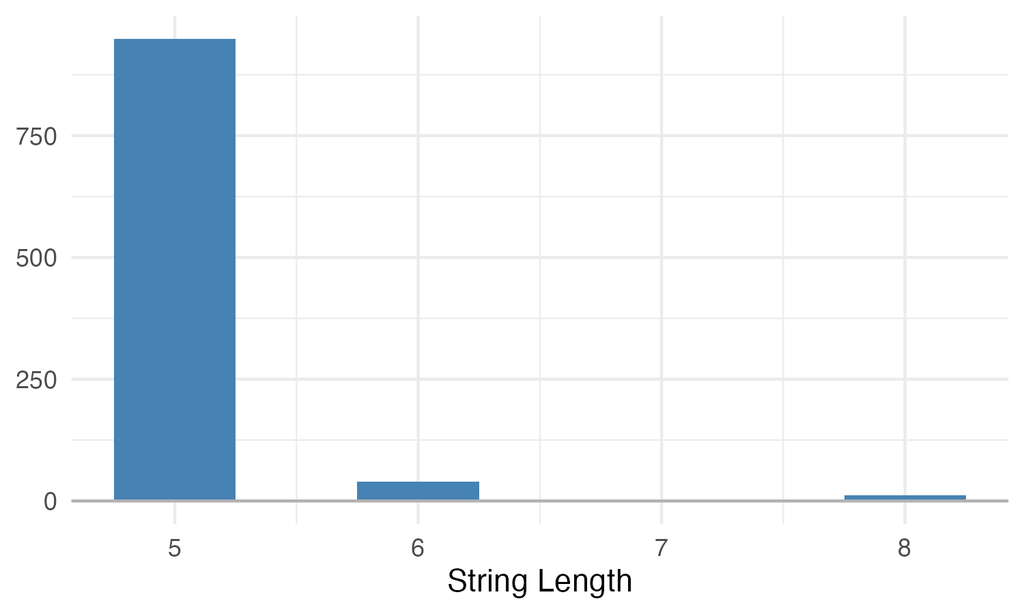

ethnicity  
`character`

| Distinct | 2 |
| --- | --- |
| `NA`s | 0 |
| `Inf`/`-Inf` | 0 |

**Common Values**

| Value | Count | Frequency |
| --- | --- | --- |
| nonhispanic | 822 | 82.2% |
| hispanic | 178 | 17.8% |
| **Other Values** (0) | 0 | 0.0% |

**String Lengths**

String Lengths

| Mean | 10.5 |
| --- | --- |
| Minimum | 8.0 |
| Maximum | 11.0 |

Histogram

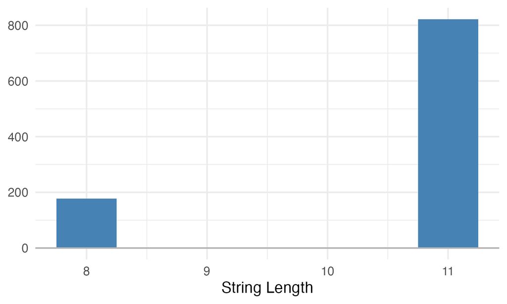

gender  
`character`

| Distinct | 2 |
| --- | --- |
| `NA`s | 0 |
| `Inf`/`-Inf` | 0 |

**Common Values**

| Value | Count | Frequency |
| --- | --- | --- |
| M | 509 | 50.9% |
| F | 491 | 49.1% |
| **Other Values** (0) | 0 | 0.0% |

**String Lengths**

String Lengths

| Mean | 1.0 |
| --- | --- |
| Minimum | 1.0 |
| Maximum | 1.0 |

Histogram

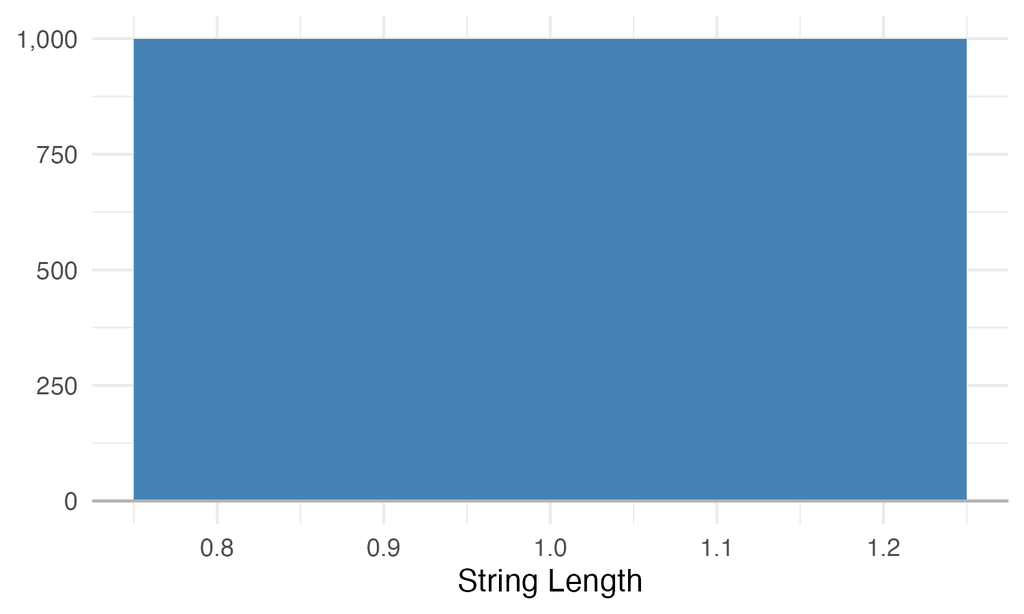

birthplace  
`character`

| Distinct | 493 |
| --- | --- |
| `NA`s | 0 |
| `Inf`/`-Inf` | 0 |

**Common Values**

| Value | Count | Frequency |
| --- | --- | --- |
| Anchorage Alaska US | 68 | 6.8% |
| Phoenix Arizona US | 30 | 3.0% |
| Little Rock Arkansas US | 20 | 2.0% |
| Montgomery Alabama US | 18 | 1.8% |
| Boston Massachusetts US | 16 | 1.6% |
| Birmingham Alabama US | 13 | 1.3% |
| Los Angeles California US | 13 | 1.3% |
| Conway Arkansas US | 9 | 0.9% |
| Fairbanks Alaska US | 9 | 0.9% |
| **Other Values** (795) | 795 | 79.5% |

**String Lengths**

String Lengths

| Mean | 23.9 |
| --- | --- |
| Minimum | 15.0 |
| Maximum | 80.0 |

Histogram

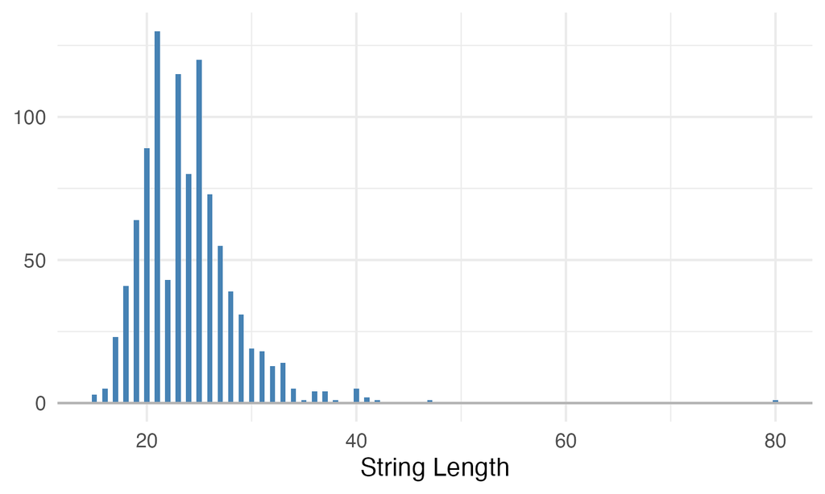

address  
`character`

| Distinct | 1,000 |
| --- | --- |
| `NA`s | 0 |
| `Inf`/`-Inf` | 0 |

**Common Values**

| Value | Count | Frequency |
| --- | --- | --- |
| 100 Hamill Fort | 1 | 0.1% |
| 100 Hermann Neck | 1 | 0.1% |
| 100 Turner Tunnel | 1 | 0.1% |
| 1002 Upton Trace Suite 89 | 1 | 0.1% |
| 1005 Jaskolski Dam | 1 | 0.1% |
| 1006 Cummings Mall | 1 | 0.1% |
| 1008 Wolf Extension Suite 31 | 1 | 0.1% |
| 101 Powlowski Byway Suite 94 | 1 | 0.1% |
| 1010 Grady Forge | 1 | 0.1% |
| **Other Values** (990) | 990 | 99.0% |

**String Lengths**

String Lengths

| Mean | 21.1 |
| --- | --- |
| Minimum | 12.0 |
| Maximum | 37.0 |

Histogram

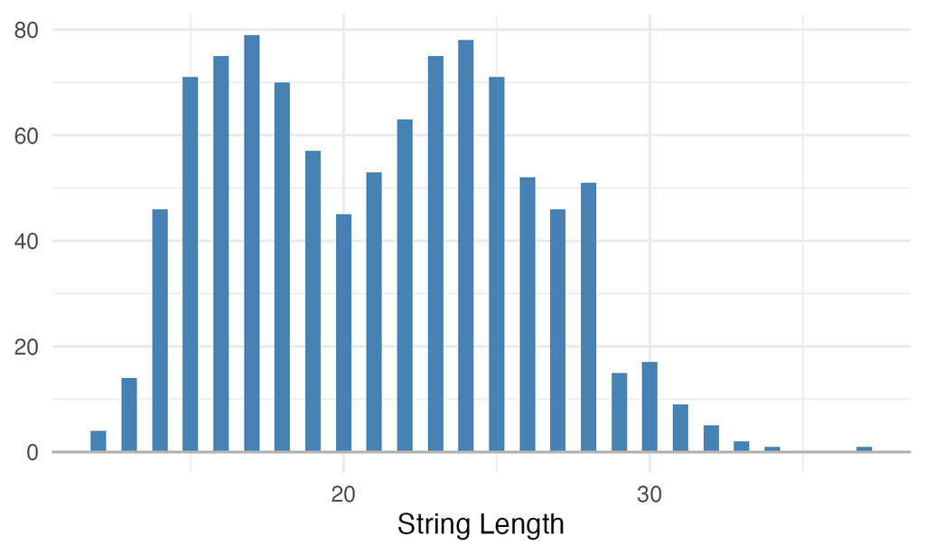

city  
`character`

| Distinct | 473 |
| --- | --- |
| `NA`s | 0 |
| `Inf`/`-Inf` | 0 |

**Common Values**

| Value | Count | Frequency |
| --- | --- | --- |
| Anchorage | 67 | 6.7% |
| Phoenix | 45 | 4.5% |
| Los Angeles | 20 | 2.0% |
| Boston | 15 | 1.5% |
| Little Rock | 15 | 1.5% |
| Gilbert | 13 | 1.3% |
| Mobile | 12 | 1.2% |
| Tempe | 11 | 1.1% |
| Conway | 10 | 1.0% |
| **Other Values** (783) | 783 | 78.3% |

**String Lengths**

String Lengths

| Mean | 8.7 |
| --- | --- |
| Minimum | 3.0 |
| Maximum | 24.0 |

Histogram

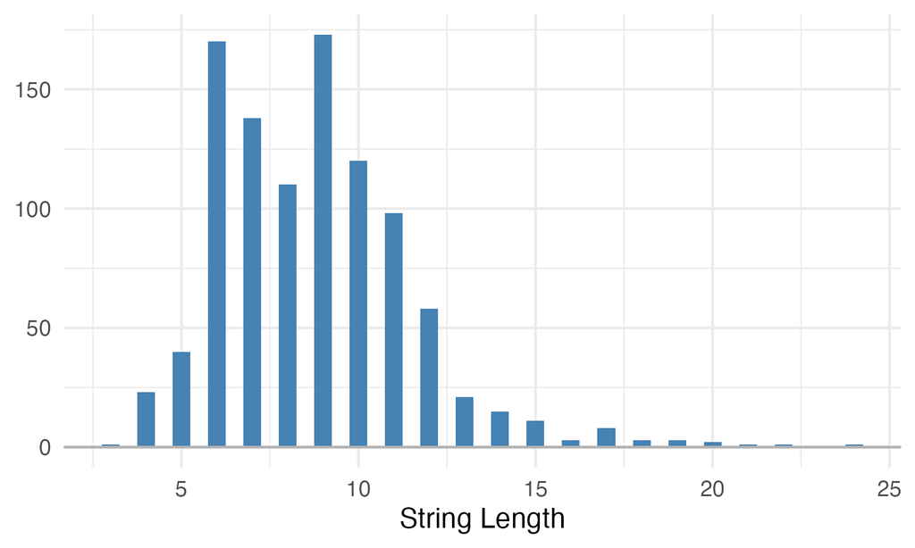

state  
`character`

| Distinct | 6 |
| --- | --- |
| `NA`s | 0 |
| `Inf`/`-Inf` | 0 |

**Common Values**

| Value | Count | Frequency |
| --- | --- | --- |
| Arizona | 176 | 17.6% |
| Alabama | 171 | 17.1% |
| Massachusetts | 171 | 17.1% |
| Arkansas | 170 | 17.0% |
| California | 166 | 16.6% |
| Alaska | 146 | 14.6% |
| **Other Values** (0) | 0 | 0.0% |

**String Lengths**

String Lengths

| Mean | 8.5 |
| --- | --- |
| Minimum | 6.0 |
| Maximum | 13.0 |

Histogram

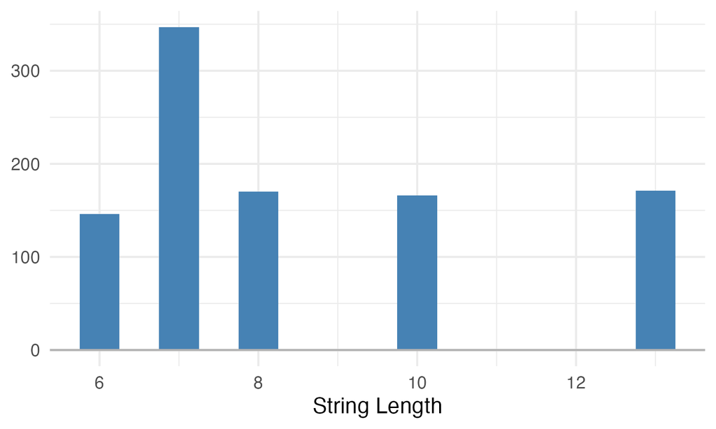

county  
`character`

| Distinct | 154 |
| --- | --- |
| `NA`s | 0 |
| `Inf`/`-Inf` | 0 |

**Common Values**

| Value | Count | Frequency |
| --- | --- | --- |
| Maricopa County | 114 | 11.4% |
| Anchorage Municipality | 67 | 6.7% |
| Middlesex County | 46 | 4.6% |
| Los Angeles County | 44 | 4.4% |
| Jefferson County | 31 | 3.1% |
| Pulaski County | 29 | 2.9% |
| Norfolk County | 21 | 2.1% |
| Pima County | 21 | 2.1% |
| Essex County | 20 | 2.0% |
| **Other Values** (588) | 588 | 58.8% |

**String Lengths**

String Lengths

| Mean | 15.9 |
| --- | --- |
| Minimum | 10.0 |
| Maximum | 33.0 |

Histogram

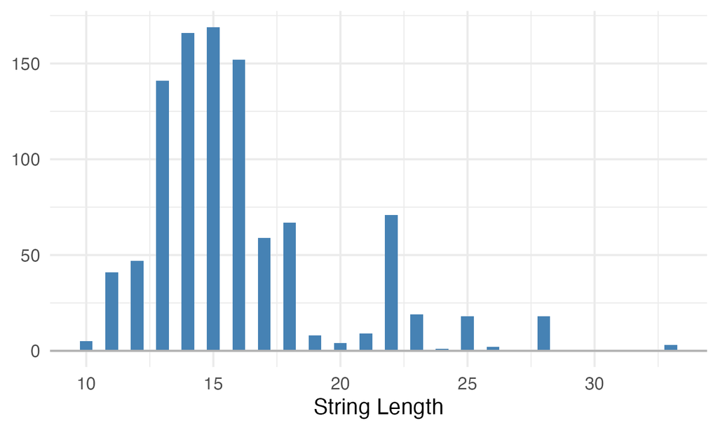

fips  
`integer`

| Distinct | 155 |
| --- | --- |
| `NA`s | 90 |
| `Inf`/`-Inf` | 0 |

| Mean | 6,799.95 |
| --- | --- |
| Minimum | 1,001 |
| Maximum | 25,027 |

**Statistics**

Quantile Statistics

| Minimum | 1,001.00 |
| --- | --- |
| 5th Percentile | 1,055.90 |
| Q1 | 2,020.00 |
| Median | 4,514.00 |
| Q3 | 6,037.00 |
| 95th Percentile | 25,021.00 |
| Maximum | 25,027.00 |
| Range | 24,026.00 |
| IQR | 4,017.00 |

Descriptive Statistics

| Mean | 6,799.95 |
| --- | --- |
| Variance | 59,316,914.79 |
| Standard Deviation | 7,701.75 |
| Coefficient of Variation | 1.13 |

**Common Values**

| Value | Count | Frequency |
| --- | --- | --- |
| 4013 | 110 | 11.0% |
| `NA` | 90 | 9.0% |
| 2020 | 67 | 6.7% |
| 6037 | 43 | 4.3% |
| 25017 | 37 | 3.7% |
| 5119 | 23 | 2.3% |
| 1073 | 21 | 2.1% |
| 5007 | 20 | 2.0% |
| 1097 | 18 | 1.8% |
| **Other Values** (553) | 553 | 55.3% |

**Max/Min Slices**

| Value | Count | Frequency |
| --- | --- | --- |
| 4013 | 110 | 11.00% |
| `NA` | 90 | 9.00% |
| 2020 | 67 | 6.70% |
| 6037 | 43 | 4.30% |
| 25017 | 37 | 3.70% |
| 5119 | 23 | 2.30% |
| 1073 | 21 | 2.10% |
| 5007 | 20 | 2.00% |
| 1097 | 18 | 1.80% |
| 25021 | 18 | 1.80% |

Minimum Values

| Value | Count | Frequency |
| --- | --- | --- |
| 1017 | 1 | 0.10% |
| 1019 | 1 | 0.10% |
| 1021 | 1 | 0.10% |
| 1023 | 1 | 0.10% |
| 1041 | 1 | 0.10% |
| 1057 | 1 | 0.10% |
| 1067 | 1 | 0.10% |
| 1087 | 1 | 0.10% |
| 1091 | 1 | 0.10% |
| 1093 | 1 | 0.10% |

zip  
`integer`

| Distinct | 645 |
| --- | --- |
| `NA`s | 0 |
| `Inf`/`-Inf` | 0 |

| Mean | 59,220.81 |
| --- | --- |
| Minimum | 0 |
| Maximum | 99,926 |

**Statistics**

Quantile Statistics

| Minimum | 0.00 |
| --- | --- |
| 5th Percentile | 0.00 |
| Q1 | 35,211.50 |
| Median | 72,452.50 |
| Q3 | 91,357.50 |
| 95th Percentile | 99,603.40 |
| Maximum | 99,926.00 |
| Range | 99,926.00 |
| IQR | 56,146.00 |

Descriptive Statistics

| Mean | 59,220.81 |
| --- | --- |
| Variance | 1,362,777,372.90 |
| Standard Deviation | 36,915.81 |
| Coefficient of Variation | 0.62 |

**Common Values**

| Value | Count | Frequency |
| --- | --- | --- |
| 0 | 90 | 9.0% |
| 99516 | 8 | 0.8% |
| 71854 | 6 | 0.6% |
| 72758 | 6 | 0.6% |
| 99504 | 6 | 0.6% |
| 99505 | 6 | 0.6% |
| 85281 | 5 | 0.5% |
| 99507 | 5 | 0.5% |
| 99540 | 5 | 0.5% |
| **Other Values** (858) | 858 | 85.8% |

**Max/Min Slices**

| Value | Count | Frequency |
| --- | --- | --- |
| 0 | 90 | 9.00% |
| 99516 | 8 | 0.80% |
| 71854 | 6 | 0.60% |
| 72758 | 6 | 0.60% |
| 99504 | 6 | 0.60% |
| 99505 | 6 | 0.60% |
| 85281 | 5 | 0.50% |
| 99507 | 5 | 0.50% |
| 99540 | 5 | 0.50% |
| 99587 | 5 | 0.50% |

Minimum Values

| Value | Count | Frequency |
| --- | --- | --- |
| 1022 | 1 | 0.10% |
| 1038 | 1 | 0.10% |
| 1062 | 1 | 0.10% |
| 1085 | 1 | 0.10% |
| 1095 | 1 | 0.10% |
| 1105 | 1 | 0.10% |
| 1107 | 1 | 0.10% |
| 1119 | 1 | 0.10% |
| 1129 | 1 | 0.10% |
| 1331 | 1 | 0.10% |

lat  
`numeric`

| Distinct | 1,000 |
| --- | --- |
| `NA`s | 0 |
| `Inf`/`-Inf` | 0 |

| Mean | 39.59 |
| --- | --- |
| Minimum | 30.29 |
| Maximum | 70.42 |

**Statistics**

Quantile Statistics

| Minimum | 30.29 |
| --- | --- |
| 5th Percentile | 31.85 |
| Q1 | 33.56 |
| Median | 34.89 |
| Q3 | 42.27 |
| 95th Percentile | 61.28 |
| Maximum | 70.42 |
| Range | 40.13 |
| IQR | 8.71 |

Descriptive Statistics

| Mean | 39.59 |
| --- | --- |
| Variance | 92.92 |
| Standard Deviation | 9.64 |
| Coefficient of Variation | 0.24 |

**Common Values**

| Value | Count | Frequency |
| --- | --- | --- |
| 30.2871955326313 | 1 | 0.1% |
| 30.3217096885329 | 1 | 0.1% |
| 30.341136265768 | 1 | 0.1% |
| 30.4145905140731 | 1 | 0.1% |
| 30.4161952079429 | 1 | 0.1% |
| 30.4309156319131 | 1 | 0.1% |
| 30.4763414624657 | 1 | 0.1% |
| 30.5877927324295 | 1 | 0.1% |
| 30.6287426912332 | 1 | 0.1% |
| **Other Values** (990) | 990 | 99.0% |

**Max/Min Slices**

| Value | Count | Frequency |
| --- | --- | --- |
| 30.28720 | 1 | 0.10% |
| 30.32171 | 1 | 0.10% |
| 30.34114 | 1 | 0.10% |
| 30.41459 | 1 | 0.10% |
| 30.41620 | 1 | 0.10% |
| 30.43092 | 1 | 0.10% |
| 30.47634 | 1 | 0.10% |
| 30.58779 | 1 | 0.10% |
| 30.62874 | 1 | 0.10% |
| 30.64043 | 1 | 0.10% |

Minimum Values

| Value | Count | Frequency |
| --- | --- | --- |
| 30.28720 | 1 | 0.10% |
| 30.32171 | 1 | 0.10% |
| 30.34114 | 1 | 0.10% |
| 30.41459 | 1 | 0.10% |
| 30.41620 | 1 | 0.10% |
| 30.43092 | 1 | 0.10% |
| 30.47634 | 1 | 0.10% |
| 30.58779 | 1 | 0.10% |
| 30.62874 | 1 | 0.10% |
| 30.64043 | 1 | 0.10% |

lon  
`numeric`

| Distinct | 1,000 |
| --- | --- |
| `NA`s | 0 |
| `Inf`/`-Inf` | 0 |

| Mean | −104.16 |
| --- | --- |
| Minimum | −171.71 |
| Maximum | −70.03 |

**Statistics**

Quantile Statistics

| Minimum | −171.71 |
| --- | --- |
| 5th Percentile | −149.89 |
| Q1 | −118.24 |
| Median | −94.34 |
| Q3 | −86.66 |
| 95th Percentile | −71.03 |
| Maximum | −70.03 |
| Range | 101.68 |
| IQR | 31.58 |

Descriptive Statistics

| Mean | −104.16 |
| --- | --- |
| Variance | 617.98 |
| Standard Deviation | 24.86 |
| Coefficient of Variation | −0.24 |

**Common Values**

| Value | Count | Frequency |
| --- | --- | --- |
| -171.705139003116 | 1 | 0.1% |
| -171.701182655105 | 1 | 0.1% |
| -166.490190528573 | 1 | 0.1% |
| -165.905428373257 | 1 | 0.1% |
| -165.567935283084 | 1 | 0.1% |
| -165.447437105211 | 1 | 0.1% |
| -164.624877321354 | 1 | 0.1% |
| -163.263314651263 | 1 | 0.1% |
| -161.975041022604 | 1 | 0.1% |
| **Other Values** (990) | 990 | 99.0% |

**Max/Min Slices**

| Value | Count | Frequency |
| --- | --- | --- |
| -171.7051 | 1 | 0.10% |
| -171.7012 | 1 | 0.10% |
| -166.4902 | 1 | 0.10% |
| -165.9054 | 1 | 0.10% |
| -165.5679 | 1 | 0.10% |
| -165.4474 | 1 | 0.10% |
| -164.6249 | 1 | 0.10% |
| -163.2633 | 1 | 0.10% |
| -161.9750 | 1 | 0.10% |
| -161.9056 | 1 | 0.10% |

Minimum Values

| Value | Count | Frequency |
| --- | --- | --- |
| -171.7051 | 1 | 0.10% |
| -171.7012 | 1 | 0.10% |
| -166.4902 | 1 | 0.10% |
| -165.9054 | 1 | 0.10% |
| -165.5679 | 1 | 0.10% |
| -165.4474 | 1 | 0.10% |
| -164.6249 | 1 | 0.10% |
| -163.2633 | 1 | 0.10% |
| -161.9750 | 1 | 0.10% |
| -161.9056 | 1 | 0.10% |

healthcare_expenses  
`numeric`

| Distinct | 986 |
| --- | --- |
| `NA`s | 0 |
| `Inf`/`-Inf` | 0 |

| Mean | 209,895.1 |
| --- | --- |
| Minimum | 100 |
| Maximum | 2,334,918.55 |

**Statistics**

Quantile Statistics

| Minimum | 100.00 |
| --- | --- |
| 5th Percentile | 2,152.93 |
| Q1 | 18,951.32 |
| Median | 95,225.49 |
| Q3 | 235,258.40 |
| 95th Percentile | 904,328.61 |
| Maximum | 2,334,918.55 |
| Range | 2,334,818.55 |
| IQR | 216,307.08 |

Descriptive Statistics

| Mean | 209,895.10 |
| --- | --- |
| Variance | 103,691,185,387.01 |
| Standard Deviation | 322,011.16 |
| Coefficient of Variation | 1.53 |

**Common Values**

| Value | Count | Frequency |
| --- | --- | --- |
| 100 | 4 | 0.4% |
| 450 | 3 | 0.3% |
| 650 | 3 | 0.3% |
| 350 | 2 | 0.2% |
| 400 | 2 | 0.2% |
| 750 | 2 | 0.2% |
| 1250 | 2 | 0.2% |
| 1850 | 2 | 0.2% |
| 2450 | 2 | 0.2% |
| **Other Values** (976) | 976 | 97.6% |

**Max/Min Slices**

| Value | Count | Frequency |
| --- | --- | --- |
| 100 | 4 | 0.40% |
| 450 | 3 | 0.30% |
| 650 | 3 | 0.30% |
| 350 | 2 | 0.20% |
| 400 | 2 | 0.20% |
| 750 | 2 | 0.20% |
| 1250 | 2 | 0.20% |
| 1850 | 2 | 0.20% |
| 2450 | 2 | 0.20% |
| 4300 | 2 | 0.20% |

Minimum Values

| Value | Count | Frequency |
| --- | --- | --- |
| 200.00 | 1 | 0.10% |
| 250.00 | 1 | 0.10% |
| 370.87 | 1 | 0.10% |
| 500.00 | 1 | 0.10% |
| 536.84 | 1 | 0.10% |
| 540.04 | 1 | 0.10% |
| 552.21 | 1 | 0.10% |
| 603.29 | 1 | 0.10% |
| 833.81 | 1 | 0.10% |
| 865.21 | 1 | 0.10% |

healthcare_coverage  
`numeric`

| Distinct | 910 |
| --- | --- |
| `NA`s | 0 |
| `Inf`/`-Inf` | 0 |

| Mean | 370,587.16 |
| --- | --- |
| Minimum | 0 |
| Maximum | 4,632,588.6 |

**Statistics**

Quantile Statistics

| Minimum | 0.00 |
| --- | --- |
| 5th Percentile | 0.00 |
| Q1 | 20,207.46 |
| Median | 121,858.18 |
| Q3 | 556,407.24 |
| 95th Percentile | 1,403,985.43 |
| Maximum | 4,632,588.60 |
| Range | 4,632,588.60 |
| IQR | 536,199.79 |

Descriptive Statistics

| Mean | 370,587.16 |
| --- | --- |
| Variance | 286,367,971,336.33 |
| Standard Deviation | 535,133.60 |
| Coefficient of Variation | 1.44 |

**Common Values**

| Value | Count | Frequency |
| --- | --- | --- |
| 0 | 91 | 9.1% |
| 112.29 | 1 | 0.1% |
| 141.69 | 1 | 0.1% |
| 147.2 | 1 | 0.1% |
| 190.75 | 1 | 0.1% |
| 191.44 | 1 | 0.1% |
| 199.1 | 1 | 0.1% |
| 290.23 | 1 | 0.1% |
| 329.49 | 1 | 0.1% |
| **Other Values** (900) | 900 | 90.0% |

**Max/Min Slices**

| Value | Count | Frequency |
| --- | --- | --- |
| 0.00 | 91 | 9.10% |
| 112.29 | 1 | 0.10% |
| 141.69 | 1 | 0.10% |
| 147.20 | 1 | 0.10% |
| 190.75 | 1 | 0.10% |
| 191.44 | 1 | 0.10% |
| 199.10 | 1 | 0.10% |
| 290.23 | 1 | 0.10% |
| 329.49 | 1 | 0.10% |
| 342.50 | 1 | 0.10% |

Minimum Values

| Value | Count | Frequency |
| --- | --- | --- |
| 112.29 | 1 | 0.10% |
| 141.69 | 1 | 0.10% |
| 147.20 | 1 | 0.10% |
| 190.75 | 1 | 0.10% |
| 191.44 | 1 | 0.10% |
| 199.10 | 1 | 0.10% |
| 290.23 | 1 | 0.10% |
| 329.49 | 1 | 0.10% |
| 342.50 | 1 | 0.10% |
| 462.17 | 1 | 0.10% |

income  
`integer`

| Distinct | 971 |
| --- | --- |
| `NA`s | 0 |
| `Inf`/`-Inf` | 0 |

| Mean | 89,445.96 |
| --- | --- |
| Minimum | 172 |
| Maximum | 984,794 |

**Statistics**

Quantile Statistics

| Minimum | 172.00 |
| --- | --- |
| 5th Percentile | 9,953.75 |
| Q1 | 26,268.75 |
| Median | 53,796.50 |
| Q3 | 98,295.50 |
| 95th Percentile | 263,435.85 |
| Maximum | 984,794.00 |
| Range | 984,622.00 |
| IQR | 72,026.75 |

Descriptive Statistics

| Mean | 89,445.96 |
| --- | --- |
| Variance | 16,425,847,653.79 |
| Standard Deviation | 128,163.36 |
| Coefficient of Variation | 1.43 |

**Common Values**

| Value | Count | Frequency |
| --- | --- | --- |
| 34699 | 3 | 0.3% |
| 66314 | 3 | 0.3% |
| 7452 | 2 | 0.2% |
| 13425 | 2 | 0.2% |
| 15795 | 2 | 0.2% |
| 16326 | 2 | 0.2% |
| 16411 | 2 | 0.2% |
| 18101 | 2 | 0.2% |
| 28635 | 2 | 0.2% |
| **Other Values** (978) | 978 | 97.8% |

**Max/Min Slices**

| Value | Count | Frequency |
| --- | --- | --- |
| 34699 | 3 | 0.30% |
| 66314 | 3 | 0.30% |
| 7452 | 2 | 0.20% |
| 13425 | 2 | 0.20% |
| 15795 | 2 | 0.20% |
| 16326 | 2 | 0.20% |
| 16411 | 2 | 0.20% |
| 18101 | 2 | 0.20% |
| 28635 | 2 | 0.20% |
| 29810 | 2 | 0.20% |

Minimum Values

| Value | Count | Frequency |
| --- | --- | --- |
| 172 | 1 | 0.10% |
| 273 | 1 | 0.10% |
| 407 | 1 | 0.10% |
| 436 | 1 | 0.10% |
| 463 | 1 | 0.10% |
| 668 | 1 | 0.10% |
| 787 | 1 | 0.10% |
| 1126 | 1 | 0.10% |
| 1141 | 1 | 0.10% |
| 1142 | 1 | 0.10% |